# ED Hydro Parameters

```r
################################################################################
# Setup the variables we are interested in

priors <- prior_load_data(download = FALSE)
variables <- c(
  "leaf_elastic_mod", "wood_elastic_mod",
  "leaf_psi_osmotic", "wood_psi_osmotic",
  "rwc_tlp_wood",
  "leaf_water_sat", "wood_water_sat",
  "leaf_water_cap", "wood_water_cap",
  "leaf_psi_min", "wood_psi_min",
  "wood_Kmax",
  "wood_psi50",
  "wood_Kexp"
)

priors <- priors %>% filter(ED_name %in% variables)

names(priors)[names(priors) == "low0.25"] <- "low.25"

stats <- c("theor.min",
           "low.025",
           "low.25",
           "mean",
           "upp.75",
           "upp.975",
           "theor.max")

priors <- priors %>% dplyr::select(one_of(
  c("ED_name",
    "Christoffersen_name",
    "BETY_variable_id",
    "BETY_prior_id",
    "ED_units",
    "Christoffersen_units",
    stats)
))

kable(priors)
```

| ED_name | Christoffersen_name | BETY_variable_id | BETY_prior_id | ED_units | Christoffersen_units | theor.min | low.025 | low.25 | mean | upp.75 | upp.975 | theor.max |
| --- | --- | --- | --- | --- | --- | --- | --- | --- | --- | --- | --- | --- |
| wood_Kexp | avuln_node | 1e+09 | 1e+09 | unitless | unitless | 0.10 | 1.00 | 10.0 | NA | 100 | 200.00 | NA |
| leaf_elastic_mod | epsil_node | 1e+09 | 1e+09 | MPa | MPa | 1.00 | 5.00 | NA | 20.00 | NA | 50.00 | NA |
| wood_elastic_mod | epsil_node | NA | NA | MPa | MPa | 1.00 | 5.00 | NA | 20.00 | NA | 50.00 | NA |
| wood_Kmax | kmax_node | 1e+09 | 1e+09 | kg H2O / m / s | kg m-1 s-1 MPa-1 | 0.01 | 0.10 | 0.5 | NA | 5 | 10.00 | NA |
| wood_psi50 | p50_node | 1e+09 | 1e+09 | m | MPa | NA | -6.00 | -4.0 | NA | -1 | -0.50 | -0.10 |
| leaf_psi_osmotic | pinot_node | 1e+09 | 1e+09 | m | MPa | NA | -4.00 | NA | -2.00 | NA | -0.50 | -0.10 |
| wood_psi_osmotic | pinot_node | 1e+09 | NA | m | MPa | NA | -4.00 | NA | -2.00 | NA | -0.50 | -0.10 |
| rwc_tlp_wood | rwctlp_node | 1e+09 | NA | unitless | unitless | NA | NA | NA | NA | NA | NA | NA |
| leaf_water_sat | thetas_node | 1e+09 | 1e+09 | kg H2O/kg biomass | kg kg-1 | 0.01 | 0.40 | NA | 0.65 | NA | 0.88 | 0.99 |
| wood_water_sat | thetas_node | 1e+09 | 1e+09 | kg H2O/kg biomass | kg kg-1 | 0.05 | 0.35 | NA | NA | NA | 0.80 | 0.90 |
| leaf_psi_min | NA | 1e+09 | 1e+09 | m | NA | NA | NA | NA | NA | NA | NA | NA |
| leaf_water_cap | NA | 1e+09 | 1e+09 | kg H2O/kg biomass/m | NA | NA | NA | NA | NA | NA | NA | NA |
| wood_psi_min | NA | 1e+09 | NA | m | NA | NA | NA | NA | NA | NA | NA | NA |
| wood_water_cap | NA | 1e+09 | 1e+09 | kg H2O/kg biomass/m | NA | NA | NA | NA | NA | NA | NA | NA |

```r
priors_converted <- priors
```

# Starting Parameters

## Liquid water density

- ED variable name : `wdns`

```r
wdns <- 1.000e3    # Liquid water density [kg/m3]
```

## Gravity

- ED variable name : `grav`

```r
grav <- 9.80665    # Gravity acceleration  [m/s2]
```

## Conversion from MPa to m

- ED variable name : `MPa2m`

```r
MPa2m <- wdns / grav
```

## Wood density

In the database, wood_density is unitless. So I’m assuming it can be directly mapped to our `wood_density` as such:

$$\frac{WD (gcm^{-2})}{\rho_w(gcm^{-2})} * \rho_w(gcm^{-2}) = \frac{WD (gcm^{-2})}{1(gcm^{-2})} * 1(gcm^{-2})$$

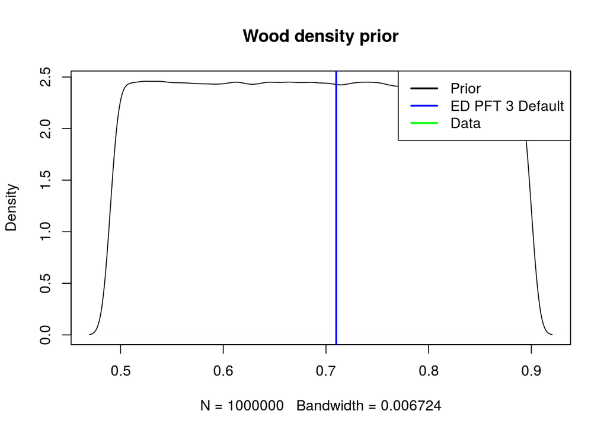

```r
wood_density_fit <- tbl(bety, "priors") %>% filter(variable_id == 1000000055) %>% filter(id == 1000000281) %>% collect()
wood_density_prior <- rdistn(wood_density_fit)
default_wood_density <- get_ED_default(PFT3_defaults_history, "rho")

plot(density(wood_density_prior), main = "Wood density prior")
abline(v = default_wood_density, col = "blue", lwd = 2)
legend("topright",legend=c("Prior","ED PFT 3 Default","Data"), col=c("black", "blue", "green"), lwd=2)
```

## Specific Leaf Area (SLA)

And subsequently $LMA = (1/SLA)$

- ED variable name : `SLA`
- ED variable id: 15

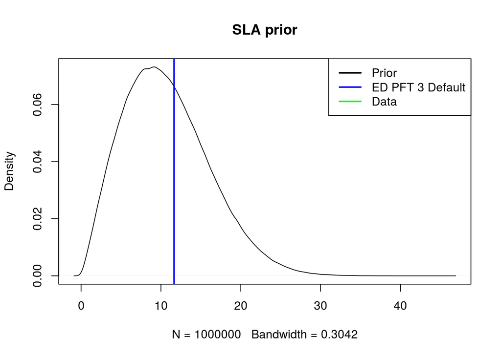

```r
SLA_fit <- tbl(bety, "priors") %>% filter(variable_id == 15) %>% filter(id == 142) %>% collect()
# In this case, we are using prior_id = 142, this was chosen by someone else and maybe we'll revisit
SLA_prior <- rdistn(SLA_fit)
plot(density(SLA_prior), main = "SLA prior")
abline(v = get_ED_default(PFT3_defaults_history, "SLA"), col = "blue", lwd = 2)
legend("topright",legend=c("Prior","ED PFT 3 Default","Data"), col=c("black", "blue", "green"), lwd=2)
```

# Key Leaf Traits

- ED variable name : `leaf_psi_osmotic`
- FATES varaiable name: `pinot_node (leaf)`

### Prior data provided by Brad Christoffersen: YES

### Conversion

`MPa to m`

Additional thoughts: All psi variables must be negative. This is difficult for the function that fits the distributions and thus I’ve experimented with flipping the data to be positive, fitting a distribution and then flipping it back. It didn’t really result in a better fitting distribution, so I chose not to change the normal distribution that I had already calculated.

```r
i <- which(priors$ED_name == "leaf_psi_osmotic")

priors_converted[i, stats] <- priors[i, stats] * MPa2m
myfit <- get_fit(priors_converted, i, plot = FALSE)
variable_id.in <- tbl(bety,"variables") %>% filter(name == priors_converted$ED_name[i]) %>% pull(id)
phylogeny.in <- "plants"
distn.in <- myfit$ssq %>% dplyr::select(one_of("Normal", "Gamma", "Log normal", "Beta")) %>%
  which.min %>% names

leaf_psi_osmotic_prior_id <- input_prior(bety, myfit, variable_id.in, phylogeny.in, distn.in)
```

```
## [1] "Entry with id = 1000000388 already exists with different parameters. Old: norm(-204.4124, 82.5231) New: norm(-204.3608, 82.5041)"
```

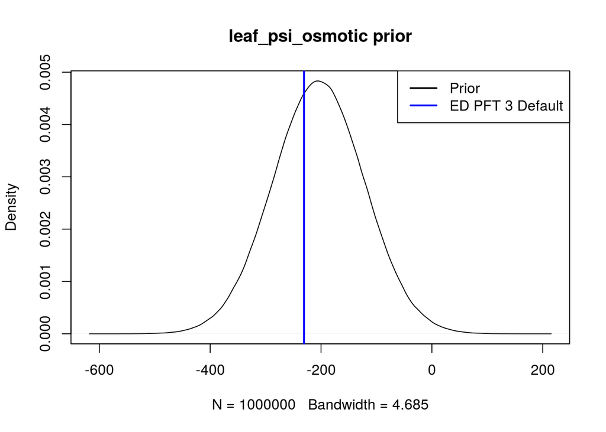

```r
leaf_psi_osmotic_fit <- tbl(bety, "priors") %>% filter(id == leaf_psi_osmotic_prior_id) %>% collect()
leaf_psi_osmotic_prior <- rdistn(leaf_psi_osmotic_fit)

plot(density(leaf_psi_osmotic_prior), main = "leaf_psi_osmotic prior")
abline(v = get_ED_default(PFT3_defaults_history, "leaf_psi_osmotic"), col = "blue", lwd = 2)
legend("topright",legend=c("Prior","ED PFT 3 Default"), col=c("black", "blue"), lwd=2)
```

```
## [1] "plotting"
```

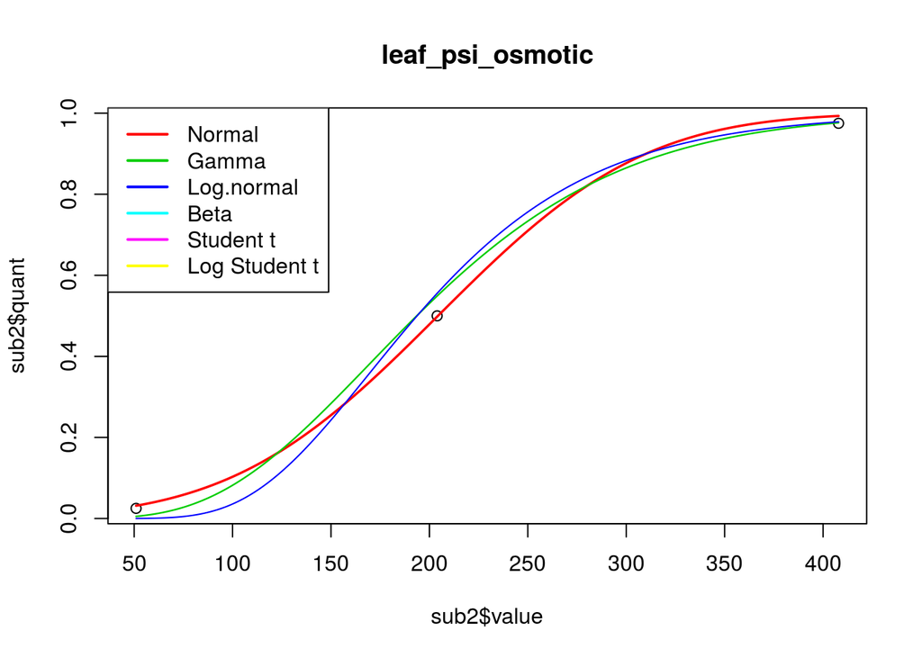

```r
#######################################################
# Experimenting with flipping things around

new.theor.min <- ifelse(!is.na(priors_converted[i,]$theor.max), -priors_converted[i,]$theor.max, NA)
new.low.025   <- ifelse(!is.na(priors_converted[i,]$upp.975), -priors_converted[i,]$upp.975, NA)
new.low.25    <- ifelse(!is.na(priors_converted[i,]$upp.75), -priors_converted[i,]$upp.75, NA)
new.mean      <- ifelse(!is.na(priors_converted[i,]$mean), -priors_converted[i,]$mean, NA)
new.upp.75    <- ifelse(!is.na(priors_converted[i,]$low.25), -priors_converted[i,]$low.25, NA)
new.upp.975   <- ifelse(!is.na(priors_converted[i,]$low.025), -priors_converted[i,]$low.025, NA)
new.theor.max <- ifelse(!is.na(priors_converted[i,]$theor.min), -priors_converted[i,]$theor.min, NA)

new <- priors_converted[i, ]
new[1,stats] <- c(new.theor.min, new.low.025, new.low.25, new.mean, new.upp.75, new.upp.975, new.theor.max)


myfit <- get_fit(new, 1, plot = TRUE) # Now there are more options
```

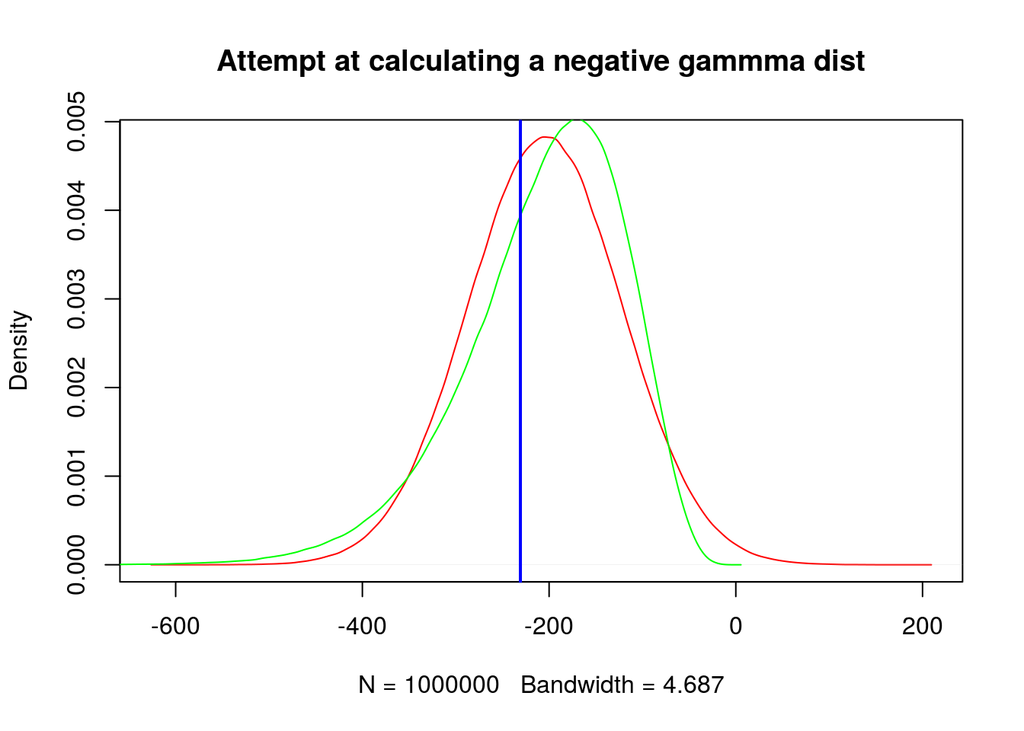

```r
# plot(density(rnorm(1000000, myfit$Normal$mean, myfit$Normal$sd)), col = "red")
# lines(density(rgamma(1000000, myfit$Gamma$shape, myfit$Gamma$rate)), col = "green")
# abline(v = -get_ED_default(PFT3_defaults_history, "leaf_psi_osmotic"), col = "blue", lwd = 2)

plot(density(rnorm(1000000, -myfit$Normal$mean, myfit$Normal$sd)), col = "red", main = "Attempt at calculating a negative gammma dist")
lines(density(-rgamma(1000000, myfit$Gamma$shape, myfit$Gamma$rate)), col = "green")
abline(v = get_ED_default(PFT3_defaults_history, "leaf_psi_osmotic"), col = "blue", lwd = 2)
```

## Leaf bulk elastic modulus

- ED variable name : `leaf_elastic_mod`
- ED variable units: `MPa` Note! This is the only case in which MPa is used instead of m!
- FATES varaiable name: `epsil_node (leaf)`

### Prior data provided by Brad Christoffersen: YES

### Conversion

None!

```
## [1] "plotting"
```

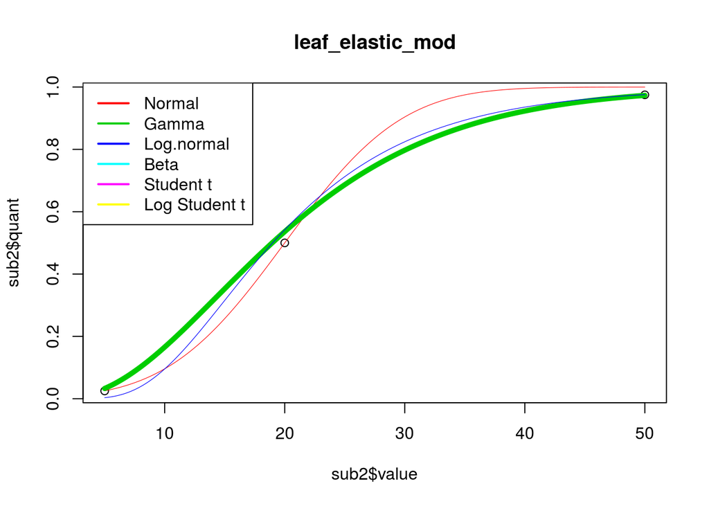

```r
i <- which(priors$ED_name == "leaf_elastic_mod")

myfit <- get_fit(priors, i, plot = TRUE)
```

```r
variable_id.in <- tbl(bety,"variables") %>% filter(name == priors$ED_name[i]) %>% pull(id)
phylogeny.in <- "plants"
distn.in <- myfit$ssq %>% dplyr::select(one_of("Normal", "Gamma", "Log normal", "Beta")) %>%
  which.min %>% names

leaf_elastic_mod_prior_id <- input_prior(bety, myfit, variable_id.in, phylogeny.in, distn.in)
```

```
## [1] "Entry with id = 1000000387 already exists with different parameters. Old: gamma(3.0791, 0.1452) New: gamma(3.0791, 0.1452)"
```

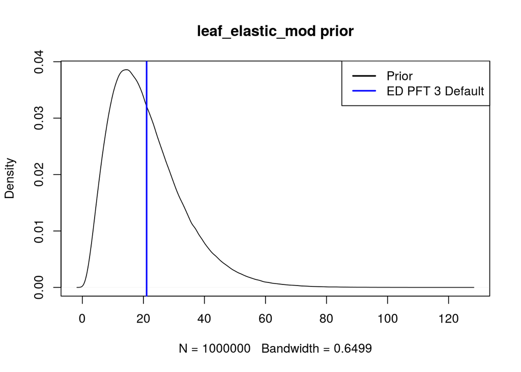

```r
leaf_elastic_mod_fit <- tbl(bety, "priors") %>% filter(id == leaf_elastic_mod_prior_id) %>% collect()
leaf_elastic_mod_prior <- rdistn(leaf_elastic_mod_fit)

plot(density(leaf_elastic_mod_prior), main = "leaf_elastic_mod prior")
abline(v = get_ED_default(PFT3_defaults_history, "leaf_elastic_mod"), col = "blue", lwd = 2)
legend("topright",legend=c("Prior","ED PFT 3 Default"), col=c("black", "blue"), lwd=2)
```

## Density of leaf tissue

- ED variable name : `leaf_density`
- ED units: `kg m-3`

```r
leaf_density_sample <- (leaf_elastic_mod_prior - 2.03) / 25.4 * 1.e3

leaf_density_sample_test <- leaf_density_sample
leaf_density_sample_test[leaf_density_sample < 100] <- NA
qs_test <- quantile(leaf_density_sample_test, c(.025,.25,.5,.75,.975), na.rm = TRUE)
myfit_test <- fitdist(vals = qs_test, probs =c(.025,.25,.5,.75,.975), lower = 100)

qs <- quantile(leaf_density_sample, c(.025,.25,.5,.75,.975), na.rm = TRUE)
myfit <- fitdist(vals = qs, probs =c(.025,.25,.5,.75,.975))

variable_id.in <- 1000000304
phylogeny.in <- "plants"
distn.in <- myfit$ssq %>% dplyr::select(one_of("Normal", "Gamma", "Log normal", "Beta")) %>%
  which.min %>% names

leaf_density_prior_id <- input_prior(bety, myfit, variable_id.in, phylogeny.in, distn.in)
```

```
## [1] "Entry with id = 1000000396 already exists with different parameters. Old: norm(695.5719, 410.5597) New: norm(695.5994, 410.9136)"
```

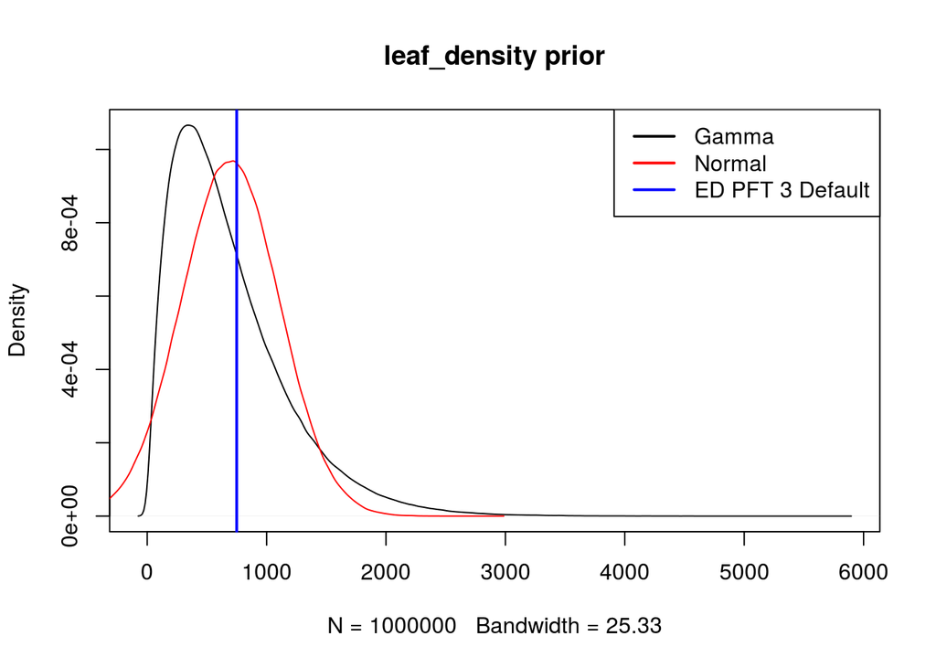

```r
leaf_density_prior_1 <- rgamma(1000000, myfit_test$Gamma$shape, myfit_test$Gamma$rate)
leaf_density_prior_2 <- rdistn(tbl(bety, "priors") %>% filter(id == 1000000396) %>% collect())
default_leaf_density <- (get_ED_default(PFT3_defaults_history, "leaf_elastic_mod") - 2.03) / 25.4 * 1.e3

plot(density(leaf_density_prior_1), main = "leaf_density prior")
lines(density(leaf_density_prior_2), col = "red")
abline(v = default_leaf_density, col = "blue", lwd = 2)
legend("topright",legend=c("Gamma", "Normal", "ED PFT 3 Default"), col=c("black", "red", "blue"), lwd=2)
```

Once again, an attempt at making a Gamma distribution that is bound at the lower limit doesn’t seem to have improved things much. Spoiler alert: I decide not to use it after experimenting with calculating leaf water content.

NOTE: I should probably remove the leaf_density Gamma dist from BETY!

## Leaf water content at saturation

- ED variable name : `leaf_water_sat`
- FATES varaiable name: `thetas_node (leaf)`

### Prior data provided by Brad Christoffersen: YES

### Conversion

There are a couple ways to approach this:

Either build a prior completely from other priors (ie using a prior for LMA and leaf_density) or try to do some sort of combination where we use the data from Brad and the prior for leaf_density.

I am going to try doing both just to see how they differ.

### Conversion

The equations between the two are identical except that to get from Christoffersen to ED, must multiply by (water density)/(leaf density)

```r
i <- which(priors$ED_name == "leaf_water_sat")

# Following the equation in ED

default_SLA <-  get_ED_default(PFT3_defaults_history, "SLA")
default_LMA <- 1e3 * 2 / default_SLA # 1.e3 * C2B / SLA(ipft)

default_leaf_water_sat <- get_ED_default(PFT3_defaults_history, "leaf_water_sat")

(-2.32e4 / default_LMA + 782.) * (1. / (-0.21 * log(1.e4 / default_LMA) + 1.43) - 1.) / default_leaf_density
```

```
## [1] 0.6342312
```

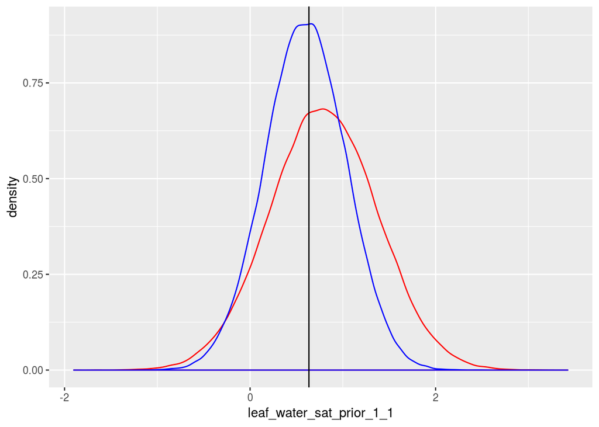

```r
LMA_prior <- 1e3 * 2 / SLA_prior

# Should be analogous to Christoffersen because I'm dividing by wdns instead of leaf_density
leaf_water_sat_samp_1_1 <- (-2.32e4 / LMA_prior + 782.) * (1. / (-0.21 * log(1.e4 / LMA_prior) + 1.43) - 1.) / leaf_density_prior_1
leaf_water_sat_samp_1_2 <- (-2.32e4 / LMA_prior + 782.) * (1. / (-0.21 * log(1.e4 / LMA_prior) + 1.43) - 1.) / leaf_density_prior_2

qs_1_1 <- quantile(leaf_water_sat_samp_1_1, c(.025,.25,.5,.75,.975), na.rm = TRUE)
qs_1_2 <- quantile(leaf_water_sat_samp_1_2, c(.025,.25,.5,.75,.975), na.rm = TRUE)

myfit_1_1 <- fitdist(vals = qs_1_1, probs = c(.025,.25,.5,.75,.975))
myfit_1_2 <- fitdist(vals = qs_1_2, probs = c(.025,.25,.5,.75,.975))

leaf_water_sat_prior_1_1 <- rnorm(100000, myfit_1_1$Normal$mean, myfit_1_1$Normal$sd)
leaf_water_sat_prior_1_2 <- rnorm(100000, myfit_1_2$Normal$mean, myfit_1_2$Normal$sd)


ggplot(data = data.frame(leaf_water_sat_prior_1_1, leaf_water_sat_prior_1_2)) +
  geom_density(aes(x = leaf_water_sat_prior_1_1), color = "red") +
  geom_density(aes(x = leaf_water_sat_prior_1_2), color = "blue") +
  geom_vline(aes(xintercept = default_leaf_water_sat))
```

```
## [1] "plotting"
```

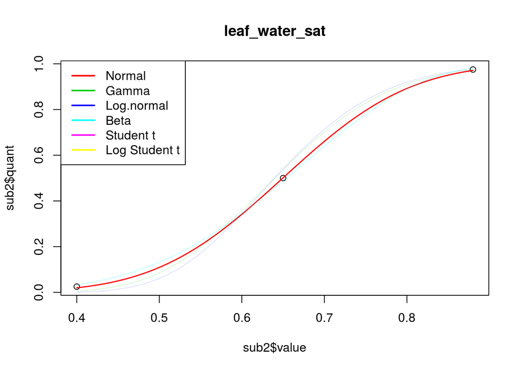

```r
myfit_2 <- get_fit(priors, i, plot = TRUE)
```

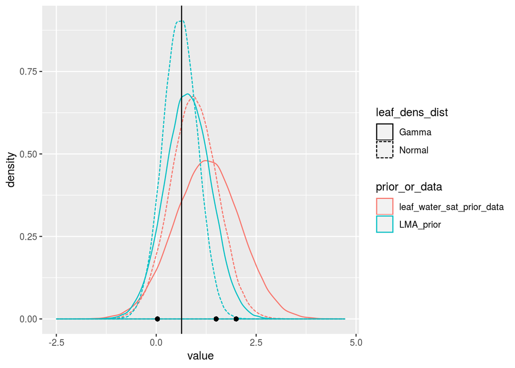

```r
leaf_water_sat_prior_2 <- rnorm(100000, myfit_2$Normal$mean, myfit_2$Normal$sd)

qs_2_1 <- quantile(leaf_water_sat_prior_2 * (wdns/(leaf_density_prior_1)), c(.025,.25,.5,.75,.975))
qs_2_2 <- quantile(leaf_water_sat_prior_2 * (wdns/(leaf_density_prior_2)), c(.025,.25,.5,.75,.975))


myfit_2_1 <- fitdist(vals = qs_2_1, probs = c(.025,.25,.5,.75,.975))
myfit_2_2 <- fitdist(vals = qs_2_2, probs = c(.025,.25,.5,.75,.975))

leaf_water_sat_prior_2_1 <- rnorm(100000, myfit_2_1$Normal$mean, myfit_2_1$Normal$sd)
leaf_water_sat_prior_2_2 <- rnorm(100000, myfit_2_2$Normal$mean, myfit_2_2$Normal$sd)

df <- data.frame(leaf_water_sat_prior_1_1, leaf_water_sat_prior_1_2,
                 # leaf_water_sat_prior_2,
                 leaf_water_sat_prior_2_1, leaf_water_sat_prior_2_2)

df2 <- df %>%
  gather(key = "prior") %>%
  mutate(leaf_dens_dist = case_when(
    prior == "leaf_water_sat_prior_1_1" ~ "Gamma",
    prior == "leaf_water_sat_prior_1_2" ~ "Normal",
    prior == "leaf_water_sat_prior_2_1" ~ "Gamma",
    prior == "leaf_water_sat_prior_2_2" ~ "Normal"
  )) %>%
  mutate(prior_or_data = case_when(
    prior == "leaf_water_sat_prior_1_1" ~ "LMA_prior",
    prior == "leaf_water_sat_prior_1_2" ~ "LMA_prior",
    prior == "leaf_water_sat_prior_2_1" ~ "leaf_water_sat_prior_data",
    prior == "leaf_water_sat_prior_2_2" ~ "leaf_water_sat_prior_data"
  ))

  ggplot(data = df2) +
  geom_density(aes(x = value, color = prior_or_data, linetype = leaf_dens_dist)) +
  geom_vline(aes(xintercept = default_leaf_water_sat)) +
  geom_point(aes(x = .03, y = 0)) + geom_point(aes(x = 1.5, y = 0)) + geom_point(aes(x = 2, y = 0))
```

In short: I choose `leaf_water_sat_prior_2_2`

```
## [1] "plotting"
```

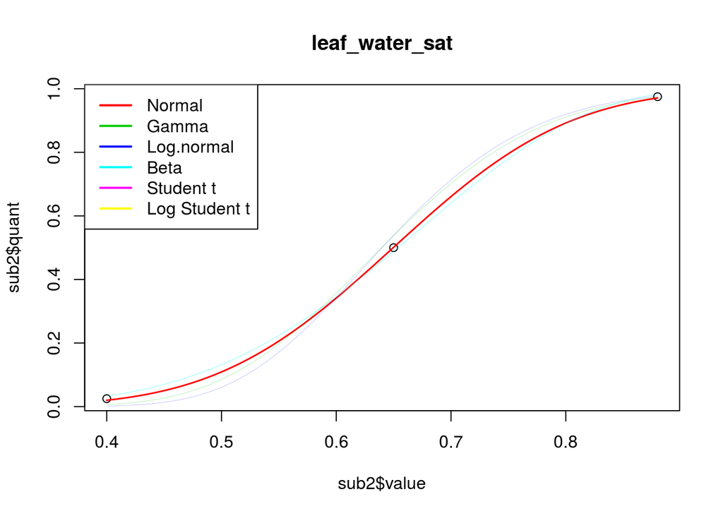

```r
leaf_density_prior <- rdistn(tbl(bety, "priors") %>% filter(id == 1000000396) %>% collect())

i <- which(priors$ED_name == "leaf_water_sat")

myfit_0 <- get_fit(priors, i, plot = TRUE)  # Ok I'm skipping an automation step here and just looking at it to see that Normal is the best fit
```

```r
leaf_water_sat_prior_0 <- rnorm(1000000, myfit_0$Normal$mean, myfit_0$Normal$sd)

qs <- quantile(leaf_water_sat_prior_0 * (wdns/(leaf_density_prior)), c(.025,.25,.5,.75,.975))
myfit <- fitdist(vals = qs, probs = c(.025,.25,.5,.75,.975))

variable_id.in <- tbl(bety,"variables") %>% filter(name == priors$ED_name[i]) %>% pull(id)
phylogeny.in <- "plants"
distn.in <- myfit$ssq %>% dplyr::select(one_of("Normal", "Gamma", "Log normal", "Beta")) %>%
  which.min %>% names
leaf_water_sat_prior_id <- input_prior(bety, myfit, variable_id.in, phylogeny.in, distn.in)
```

```
## [1] "Entry with id = 1000000358 already exists with different parameters. Old: norm(0.9420, 0.5958) New: norm(0.9419, 0.5946)"
```

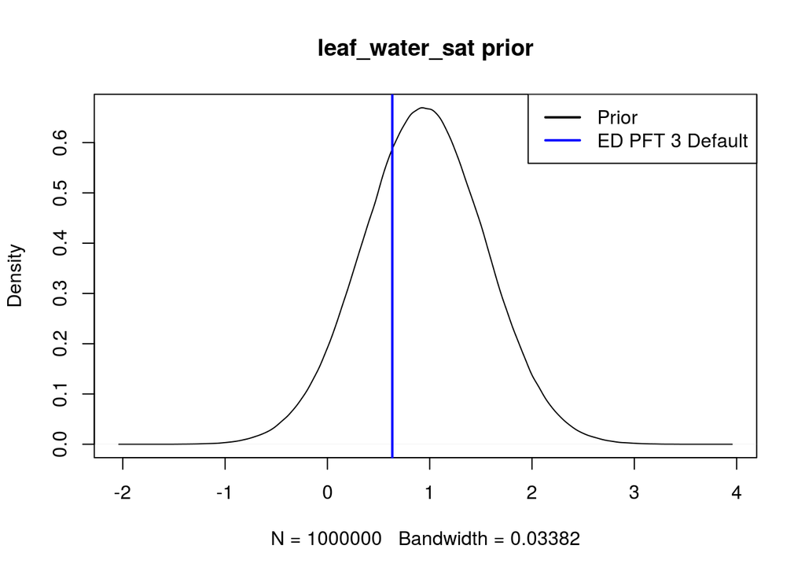

```r
leaf_water_sat_fit <- tbl(bety, "priors") %>% filter(id == leaf_water_sat_prior_id) %>% collect()
leaf_water_sat_prior <- rdistn(leaf_water_sat_fit)

plot(density(leaf_water_sat_prior), main = "leaf_water_sat prior")
abline(v = get_ED_default(PFT3_defaults_history, "leaf_water_sat"), col = "blue", lwd = 2)
legend("topright",legend=c("Prior","ED PFT 3 Default"), col=c("black", "blue"), lwd=2)
```

## leaf_psi_tlp

- ED variable name : `leaf_psi_tlp`

### Calculation and conversion

This one is calculated purely from other parameters: `leaf_psi_osmotic` and `leaf_elastic_mod`

Remember that `leaf_elastic_mod` is `MPa`, where everything else is `m`!

```r
leaf_psi_tlp_samp <-
  (leaf_psi_osmotic_prior*leaf_elastic_mod_prior*MPa2m)/
  (leaf_psi_osmotic_prior+leaf_elastic_mod_prior*MPa2m)

qs <- quantile(leaf_psi_tlp_samp, c(.025,.25,.5,.75,.975))
myfit <- fitdist(vals = qs, probs =c(.025,.25,.5,.75,.975))

variable_id.in <- tbl(bety, "variables") %>% filter(name == "leaf_psi_tlp") %>% pull(id)
phylogeny.in <- "plants"
distn.in <- myfit$ssq %>% dplyr::select(one_of("Normal", "Gamma", "Log normal", "Beta")) %>%
  which.min %>% names

leaf_psi_tlp_prior_id <- input_prior(bety, myfit, variable_id.in, phylogeny.in, distn.in)
```

```
## [1] "Entry with id = 1000000384 already exists with different parameters. Old: norm(-235.6222, 109.6489) New: norm(-236.0671, 109.6511)"
```

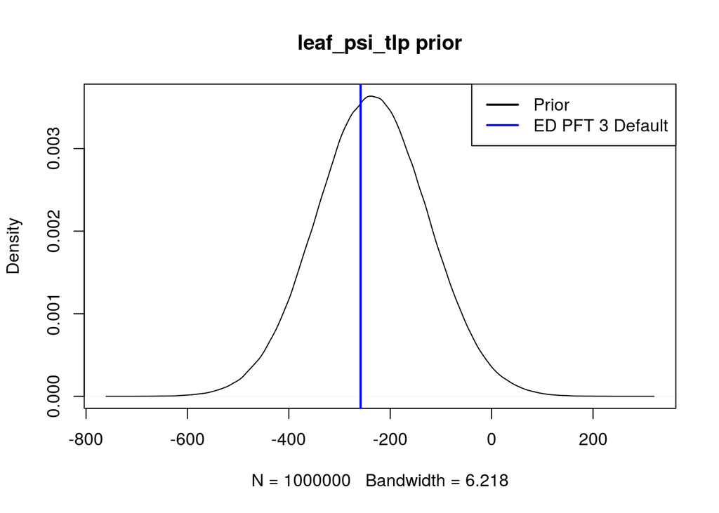

```r
leaf_psi_tlp_fit <- tbl(bety, "priors") %>% filter(id == leaf_psi_tlp_prior_id) %>% collect()
leaf_psi_tlp_prior <- rdistn(leaf_psi_tlp_fit)

plot(density(leaf_psi_tlp_prior), main = "leaf_psi_tlp prior")
abline(v = get_ED_default(PFT3_defaults_history, "leaf_psi_tlp"), col = "blue", lwd = 2)
legend("topright",legend=c("Prior","ED PFT 3 Default"), col=c("black", "blue"), lwd=2)
```

## leaf_water_cap

- ED variable name : `leaf_water_cap`

### Calculation

Calculated entirely from priors

```r
leaf_water_cap_samp <-
  (1 - leaf_psi_osmotic_prior / (4 * leaf_psi_tlp_prior)) *
  (leaf_water_sat_prior / (4 * abs(leaf_psi_tlp_prior)))

qs <- quantile(leaf_water_cap_samp, c(.025,.25,.5,.75,.975))
myfit <- fitdist(vals = qs, probs =c(.025,.25,.5,.75,.975))

variable_id.in <- tbl(bety, "variables") %>% filter(name == "leaf_water_cap") %>% pull(id)
phylogeny.in <- "plants"
distn.in <- myfit$ssq %>% dplyr::select(one_of("Normal", "Gamma", "Log normal", "Beta")) %>%
  which.min %>% names

leaf_water_cap_prior_id <- input_prior(bety, myfit, variable_id.in, phylogeny.in, distn.in)
```

```
## [1] "Entry with id = 1000000390 already exists with different parameters. Old: norm(0.0007, 0.0006) New: norm(0.0007, 0.0006)"
```

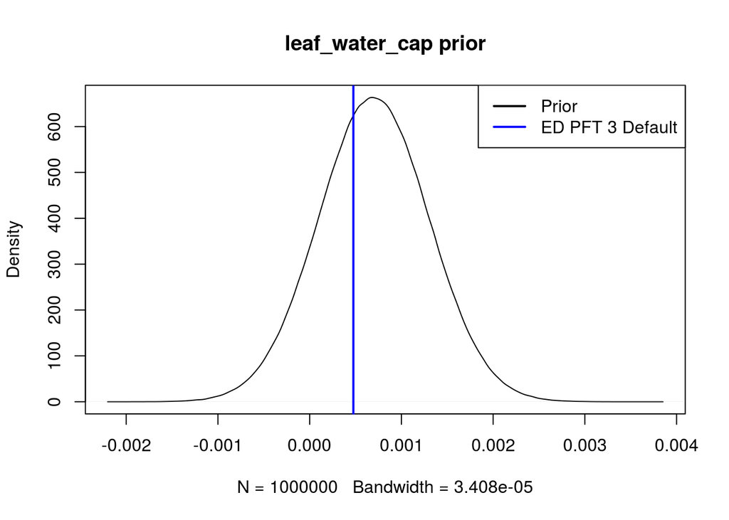

```r
leaf_water_cap_fit <- tbl(bety, "priors") %>% filter(id == leaf_water_cap_prior_id) %>% collect()
leaf_water_cap_prior <- rdistn(leaf_water_cap_fit)

plot(density(leaf_water_cap_prior), main = "leaf_water_cap prior")
abline(v = get_ED_default(PFT3_defaults_history, "leaf_water_cap"), col = "blue", lwd = 2)
legend("topright",legend=c("Prior","ED PFT 3 Default"), col=c("black", "blue"), lwd=2)
```

## leaf_psi_min

- ED variable name : `leaf_psi_min`

### Calculation

Should I put rwc_min in the database too?

```r
leaf_rwc_min_samp = 0.01 * leaf_elastic_mod_prior + 0.17
leaf_psi_min_samp = (leaf_rwc_min_samp - 1.) * leaf_water_sat_prior / leaf_water_cap_prior

qs <- quantile(leaf_psi_min_samp, c(.025,.25,.5,.75,.975))
myfit <- fitdist(vals = qs, probs =c(.025,.25,.5,.75,.975))

variable_id.in <- tbl(bety, "variables") %>% filter(name == "leaf_psi_min") %>% pull(id)
phylogeny.in <- "plants"
distn.in <- myfit$ssq %>% dplyr::select(one_of("Normal", "Gamma", "Log normal", "Beta")) %>%
  which.min %>% names

leaf_psi_min_prior_id <- input_prior(bety, myfit, variable_id.in, phylogeny.in, distn.in)
```

```
## [1] "Entry with id = 1000000392 already exists with different parameters. Old: norm(-665.9526, 773.5656) New: norm(-667.1668, 774.0183)"
```

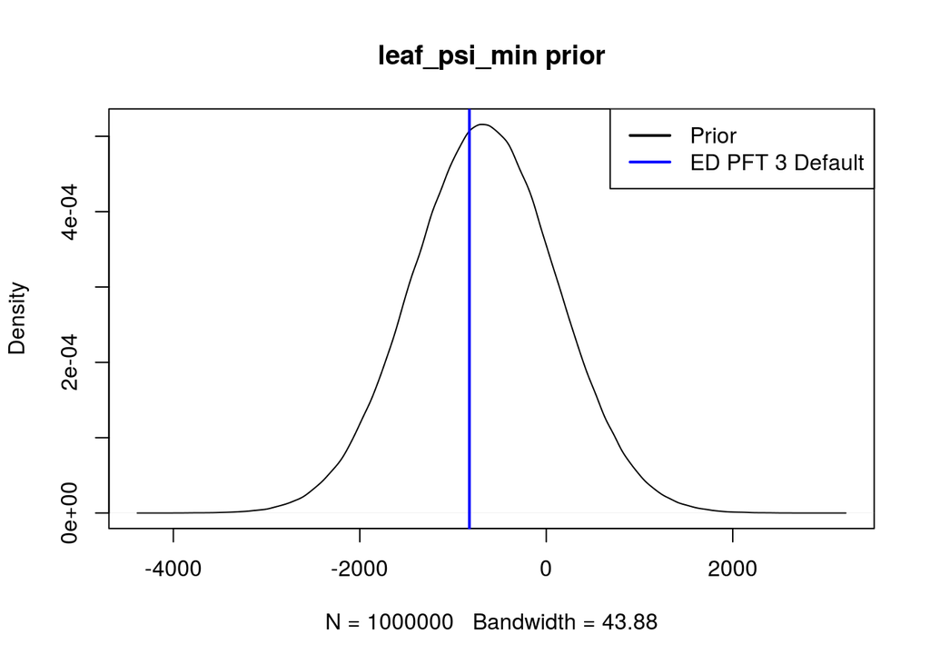

```r
leaf_psi_min_fit <- tbl(bety, "priors") %>% filter(id == leaf_psi_min_prior_id) %>% collect()
leaf_psi_min_prior <- rdistn(leaf_psi_min_fit)

plot(density(leaf_psi_min_prior), main = "leaf_psi_min prior")
abline(v = get_ED_default(PFT3_defaults_history, "leaf_psi_min"), col = "blue", lwd = 2)
legend("topright",legend=c("Prior","ED PFT 3 Default"), col=c("black", "blue"), lwd=2)
```

## ——————————————————————————–

## ——————————————————————————–

## ——————————————————————————–

# Key Wood Traits

- ED variable name : `wood_psi_osmotic`
- FATES varaiable name: `pinot_node (stem)`

### Prior data provided by Brad Christoffersen: YES

### Conversion

`MPa to m`

```
## [1] "plotting"
```

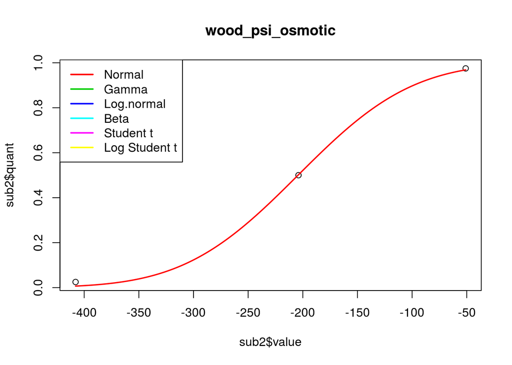

```r
i <- which(priors$ED_name == "wood_psi_osmotic")
priors[i, stats] <- priors[i, stats] * MPa2m

myfit <- get_fit(priors, i, plot = TRUE)
```

```r
variable_id.in <- tbl(bety,"variables") %>% filter(name == priors$ED_name[i]) %>% pull(id)
phylogeny.in <- "plants"
distn.in <- myfit$ssq %>% dplyr::select(one_of("Normal", "Gamma", "Log normal", "Beta")) %>%
  which.min %>% names

wood_psi_osmotic_prior_id <- input_prior(bety, myfit, variable_id.in, phylogeny.in, distn.in)
```

```
## [1] "Entry with id = 1000000393 already exists with different parameters. Old: norm(-204.3608, 82.5041) New: norm(-204.3608, 82.5041)"
```

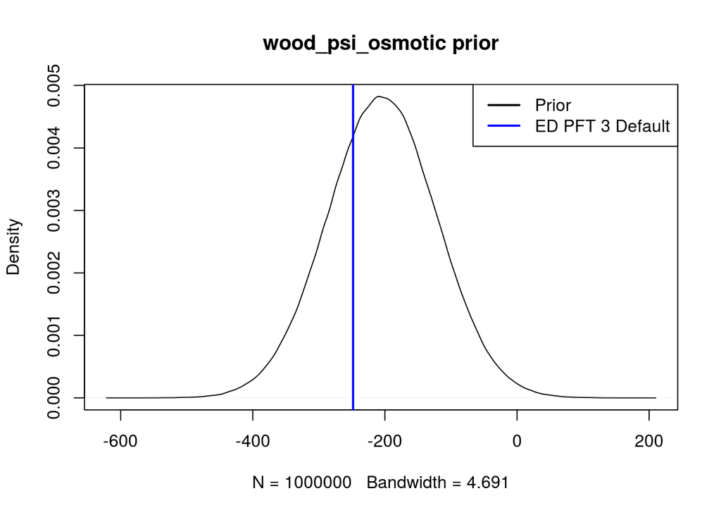

```r
wood_psi_osmotic_fit <- tbl(bety, "priors") %>% filter(id == wood_psi_osmotic_prior_id) %>% collect()
wood_psi_osmotic_prior <- rdistn(wood_psi_osmotic_fit)

plot(density(wood_psi_osmotic_prior), main = "wood_psi_osmotic prior")
abline(v = get_ED_default(PFT3_defaults_history, "wood_psi_osmotic"), col = "blue", lwd = 2)
legend("topright",legend=c("Prior","ED PFT 3 Default"), col=c("black", "blue"), lwd=2)
```

## wood_elastic_mod

- ED variable name : `wood_elastic_mod`
- ED variable units: `MPa` Note! This is the only case in which MPa is used instead of m!
- FATES varaiable name: `epsil_node (stem)`

### Prior data provided by Brad Christoffersen: YES

### Conversion

None

```
## [1] "plotting"
```

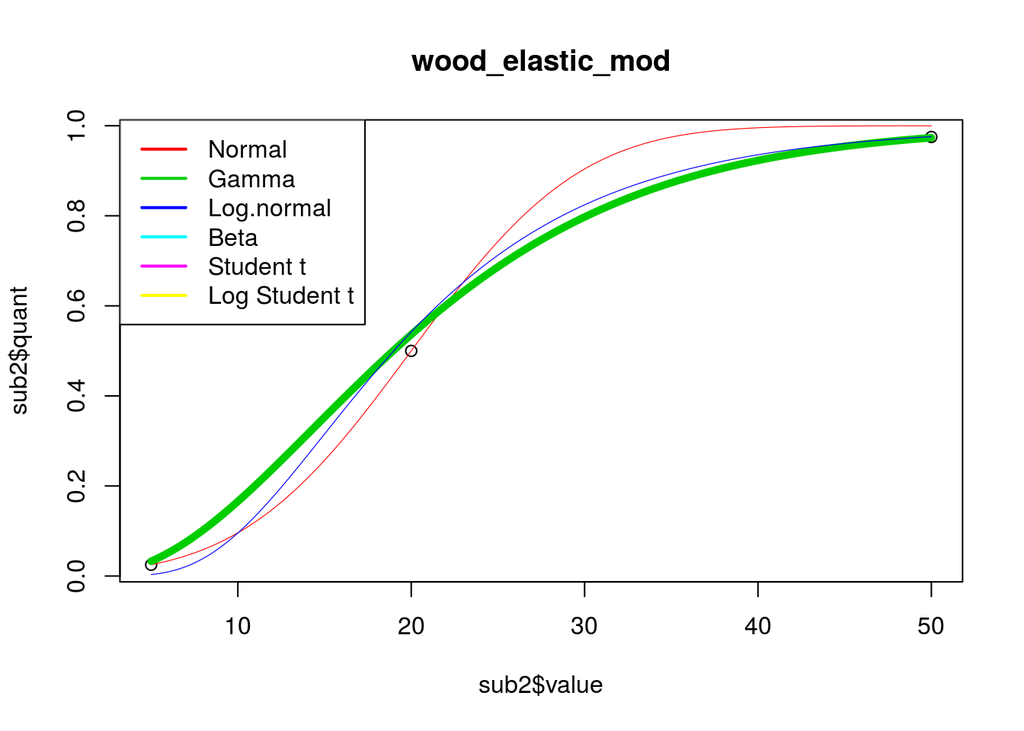

```r
i <- which(priors$ED_name == "wood_elastic_mod")

myfit <- get_fit(priors, i, plot = TRUE)
```

```r
variable_id.in <- tbl(bety,"variables") %>% filter(name == priors$ED_name[i]) %>% pull(id)
phylogeny.in <- "plants"
distn.in <- myfit$ssq %>% dplyr::select(one_of("Normal", "Gamma", "Log normal", "Beta")) %>%
  which.min %>% names

wood_elastic_mod_prior_id <- input_prior(bety, myfit, variable_id.in, phylogeny.in, distn.in)
```

```
## [1] "Entry with id = 1000000394 already exists with different parameters. Old: gamma(3.0791, 0.1452) New: gamma(3.0791, 0.1452)"
```

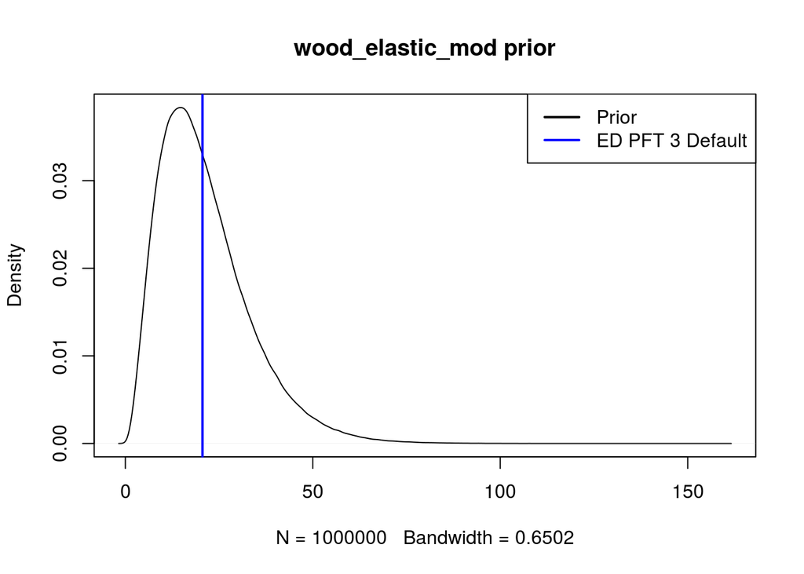

```r
wood_elastic_mod_fit <- tbl(bety, "priors") %>% filter(id == wood_elastic_mod_prior_id) %>% collect()
wood_elastic_mod_prior <- rdistn(wood_elastic_mod_fit)

plot(density(wood_elastic_mod_prior), main = "wood_elastic_mod prior")
abline(v = get_ED_default(PFT3_defaults_history, "wood_elastic_mod"), col = "blue", lwd = 2)
legend("topright",legend=c("Prior","ED PFT 3 Default"), col=c("black", "blue"), lwd=2)
```

## Sapwood water content at saturation

- ED variable name : `wood_water_sat`
- FATES varaiable name: `thetas_node (stem)`

### Prior data provided by Brad Christoffersen: YES

### Conversion

This is the version cousin of leaf water content at saturation.

```
## [1] "plotting"
```

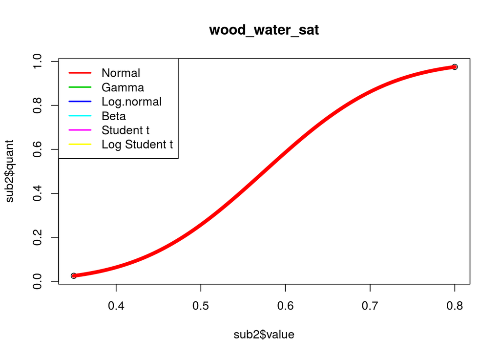

```r
i <- which(priors$ED_name == "wood_water_sat")

myfit_0 <- get_fit(priors, i, plot = TRUE)  # Ok I'm skipping an automation step here and just looking at it to see that Normal is the best fit
```

```r
wood_water_sat_prior_0 <- rnorm(1000000, myfit_0$Normal$mean, myfit_0$Normal$sd)

wdns/mean(wood_density_prior* 1e3)
```

```
## [1] 1.439089
```

```r
qs <- quantile(wood_water_sat_prior_0 * (wdns/(wood_density_prior * 1e3)), c(.025,.25,.5,.75,.975))
myfit <- fitdist(vals = qs, probs = c(.025,.25,.5,.75,.975))

variable_id.in <- tbl(bety,"variables") %>% filter(name == priors$ED_name[i]) %>% pull(id)
phylogeny.in <- "plants"
distn.in <- myfit$ssq %>% dplyr::select(one_of("Normal", "Gamma", "Log normal", "Beta")) %>%
  which.min %>% names
wood_water_sat_prior_id <- input_prior(bety, myfit, variable_id.in, phylogeny.in, distn.in)
```

```
## [1] "Entry with id = 1000000359 already exists with different parameters. Old: norm(0.8368, 0.2212) New: norm(0.8368, 0.2213)"
```

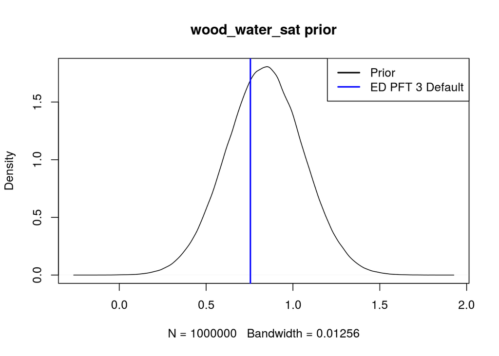

```r
wood_water_sat_fit <- tbl(bety, "priors") %>% filter(id == wood_water_sat_prior_id) %>% collect()
wood_water_sat_prior <- rdistn(wood_water_sat_fit)

plot(density(wood_water_sat_prior), main = "wood_water_sat prior")
abline(v = get_ED_default(PFT3_defaults_history, "wood_water_sat"), col = "blue", lwd = 2)
legend("topright",legend = c("Prior","ED PFT 3 Default"), col=c("black", "blue"), lwd = 2)
```

## wood_psi_tlp

- ED variable name : `wood_psi_tlp`

### Calculation and conversion

This one is calculated purely from other parameters: `wood_psi_osmotic` and `wood_elastic_mod`

Remember that `wood_elastic_mod` is `MPa`, where everything else is `m`!

```r
wood_psi_tlp_samp <-
  (wood_psi_osmotic_prior*wood_elastic_mod_prior*MPa2m)/
  (wood_psi_osmotic_prior+wood_elastic_mod_prior*MPa2m)

qs <- quantile(wood_psi_tlp_samp, c(.025,.25,.5,.75,.975))
myfit <- fitdist(vals = qs, probs =c(.025,.25,.5,.75,.975))

variable_id.in <- tbl(bety, "variables") %>% filter(name == "wood_psi_tlp") %>% pull(id)
phylogeny.in <- "plants"
distn.in <- myfit$ssq %>% dplyr::select(one_of("Normal", "Gamma", "Log normal", "Beta")) %>%
  which.min %>% names

wood_psi_tlp_prior_id <- input_prior(bety, myfit, variable_id.in, phylogeny.in, distn.in)
```

```
## [1] "Entry with id = 1000000400 already exists with different parameters. Old: norm(-235.9700, 109.8376) New: norm(-235.7169, 109.6094)"
```

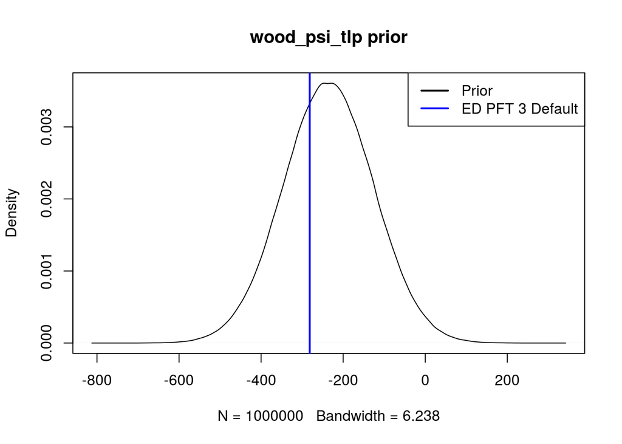

```r
wood_psi_tlp_fit <- tbl(bety, "priors") %>% filter(id == wood_psi_tlp_prior_id) %>% collect()
wood_psi_tlp_prior <- rdistn(wood_psi_tlp_fit)

plot(density(wood_psi_tlp_prior), main = "wood_psi_tlp prior")
abline(v = get_ED_default(PFT3_defaults_history, "wood_psi_tlp"), col = "blue", lwd = 2)
legend("topright",legend=c("Prior","ED PFT 3 Default"), col=c("black", "blue"), lwd=2)
```

## wood_water_cap

- ED variable name : `wood_water_cap`

### Calculation

Calculated entirely from priors

```r
wood_water_cap_samp <-
  (1 - wood_psi_osmotic_prior / (4 * wood_psi_tlp_prior)) *
  (wood_water_sat_prior / (4 * abs(wood_psi_tlp_prior)))

qs <- quantile(wood_water_cap_samp, c(.025,.25,.5,.75,.975))
myfit <- fitdist(vals = qs, probs =c(.025,.25,.5,.75,.975))

variable_id.in <- tbl(bety, "variables") %>% filter(name == "wood_water_cap") %>% pull(id)
phylogeny.in <- "plants"
distn.in <- myfit$ssq %>% dplyr::select(one_of("Normal", "Gamma", "Log normal", "Beta")) %>%
  which.min %>% names

wood_water_cap_prior_id <- input_prior(bety, myfit, variable_id.in, phylogeny.in, distn.in)
```

```
## [1] "Entry with id = 1000000391 already exists with different parameters. Old: norm(0.0006, 0.0002) New: norm(0.0007, 0.0003)"
```

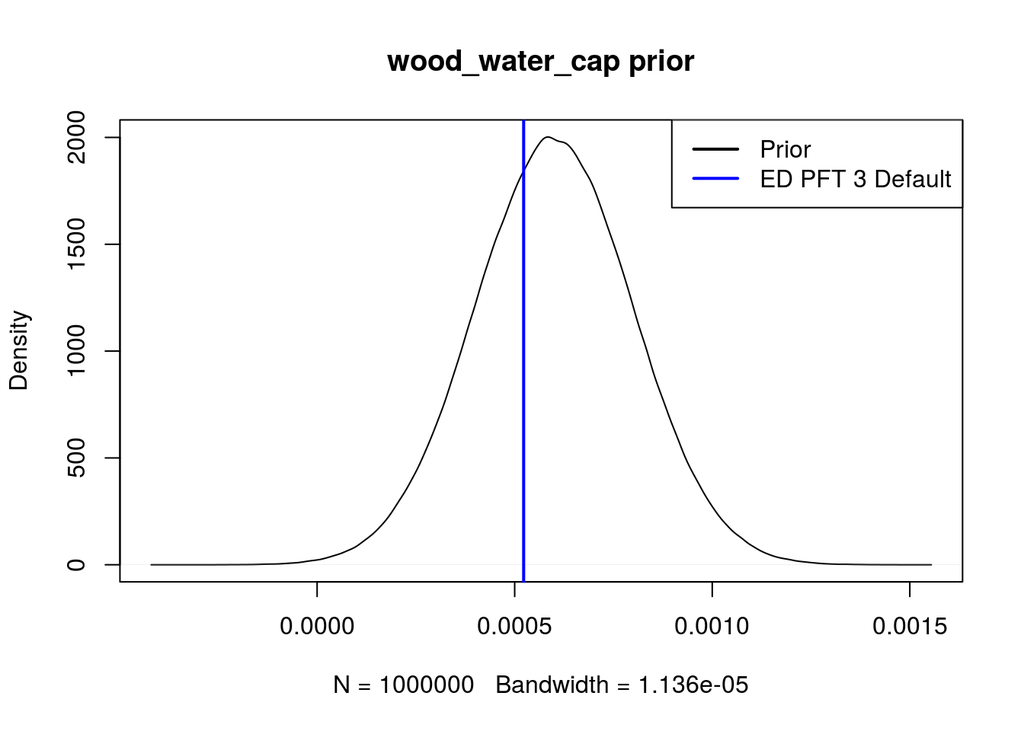

```r
wood_water_cap_fit <- tbl(bety, "priors") %>% filter(id == wood_water_cap_prior_id) %>% collect()
wood_water_cap_prior <- rdistn(wood_water_cap_fit)

plot(density(wood_water_cap_prior), main = "wood_water_cap prior")
abline(v = get_ED_default(PFT3_defaults_history, "wood_water_cap"), col = "blue", lwd = 2)
legend("topright",legend=c("Prior","ED PFT 3 Default"), col=c("black", "blue"), lwd=2)
```

## Kmax

I’m still pretty sure I need to multiply by the density of water It sure looks a lot better

```r
i <- which(priors$ED_name == "wood_Kmax")

priors_converted[i, stats] <- priors[i, stats] * wdns / MPa2m
# priors_converted[i, stats] <- priors[i, stats] * 1 / MPa2m
myfit <- get_fit(priors_converted, i, plot = FALSE)
variable_id.in <- tbl(bety,"variables") %>% filter(name == priors$ED_name[i]) %>% pull(id)
phylogeny.in <- "plants"
distn.in <- myfit$ssq %>% dplyr::select(one_of("Normal", "Gamma", "Log normal", "Beta")) %>%
  which.min %>% names

wood_Kmax_prior_id <- input_prior(bety, myfit, variable_id.in, phylogeny.in, distn.in)
```

```
## [1] "Entry with id = 1000000357 already exists with different parameters. Old: gamma(0.7101, 0.0223) New: gamma(0.7101, 0.0223)"
```

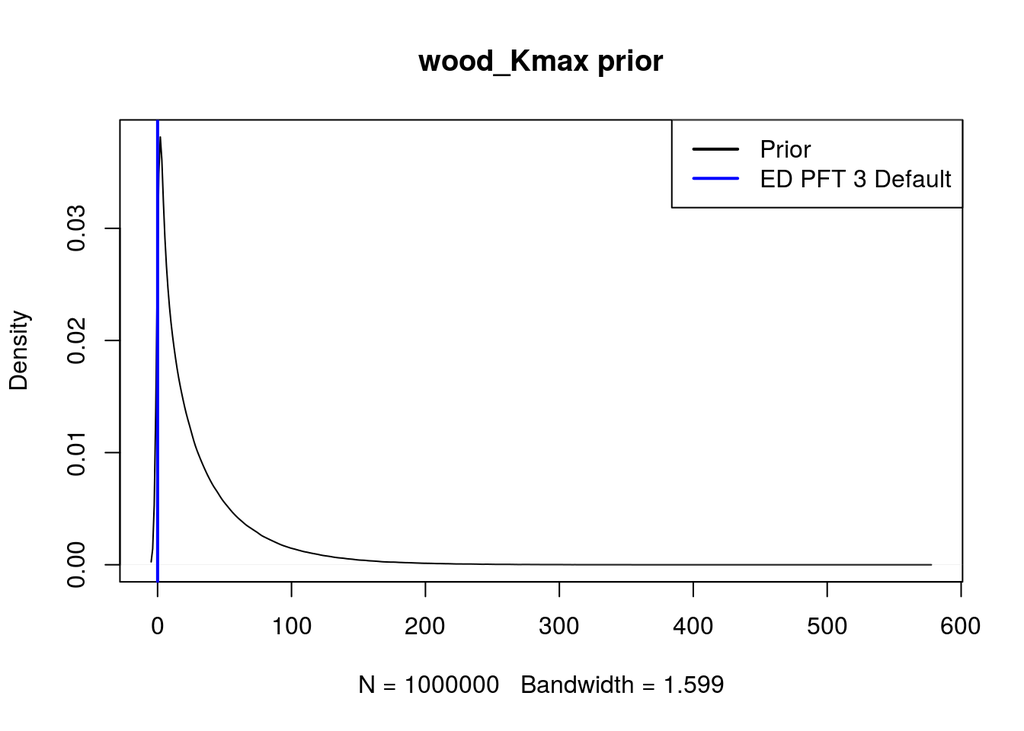

```r
wood_Kmax_fit <- tbl(bety, "priors") %>% filter(id == wood_Kmax_prior_id) %>% collect()
wood_Kmax_prior <- rdistn(wood_Kmax_fit)

plot(density(wood_Kmax_prior), main = "wood_Kmax prior")
abline(v = get_ED_default(PFT3_defaults_history, "wood_Kmax"), col = "blue", lwd = 2)
legend("topright",legend=c("Prior","ED PFT 3 Default"), col=c("black", "blue"), lwd=2)
```

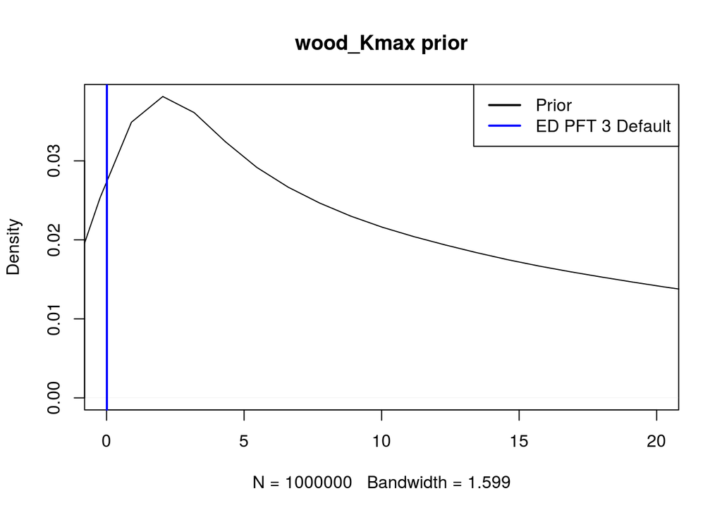

```r
plot(density(wood_Kmax_prior), main = "wood_Kmax prior", xlim = c(0, 20))
abline(v = get_ED_default(PFT3_defaults_history, "wood_Kmax"), col = "blue", lwd = 2)
legend("topright",legend=c("Prior","ED PFT 3 Default"), col=c("black", "blue"), lwd=2)
```

## psi50

```r
i <- which(priors$ED_name == "wood_psi50")

priors_converted[i, stats] <- priors[i, stats] * MPa2m
myfit <- get_fit(priors_converted, i, plot = FALSE)
variable_id.in <- tbl(bety,"variables") %>% filter(name == priors$ED_name[i]) %>% pull(id)
phylogeny.in <- "plants"
distn.in <- myfit$ssq %>% dplyr::select(one_of("Normal", "Gamma", "Log normal", "Beta")) %>%
  which.min %>% names

wood_psi50_prior_id <- input_prior(bety, myfit, variable_id.in, phylogeny.in, distn.in)
```

```
## [1] "Entry with id = 1000000360 already exists with different parameters. Old: norm(-275.8538, 184.6259) New: norm(-275.8538, 184.6259)"
```

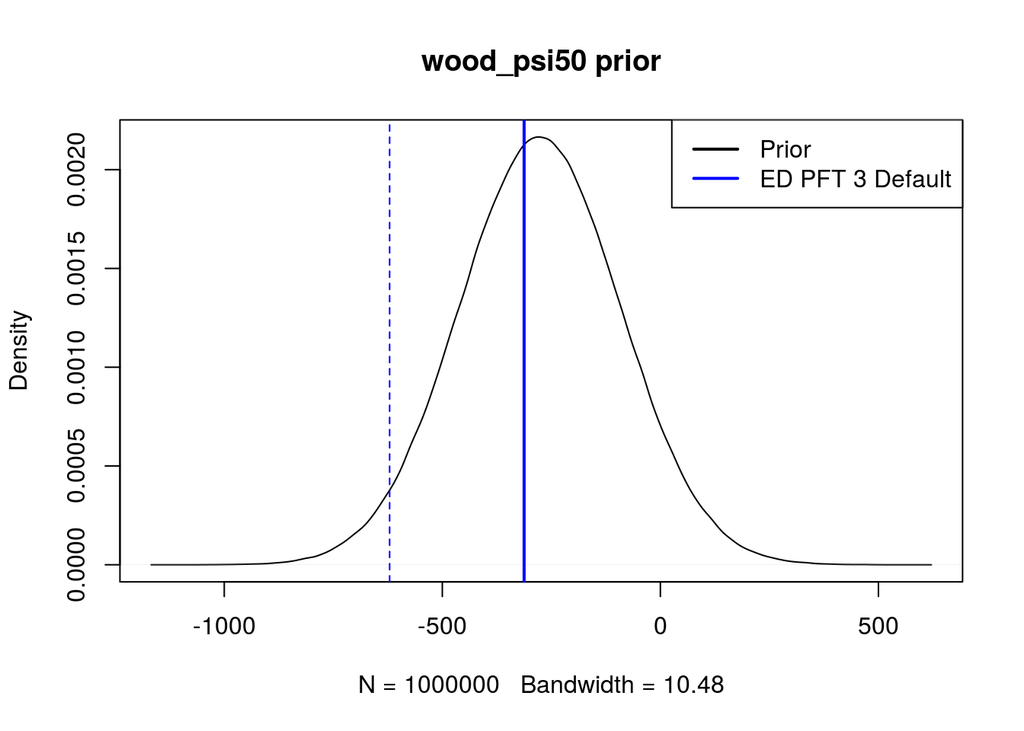

```r
wood_psi50_fit <- tbl(bety, "priors") %>% filter(id == wood_psi50_prior_id) %>% collect()
wood_psi50_prior <- rdistn(wood_psi50_fit)

# Calculating this by hand because it is calculated wrong in ED!
default_wood_psi50 <- (-1.09 - (3.57 * default_wood_density ^ 1.73)) * MPa2m
wrong_default_wood_psi50 <- get_ED_default(PFT3_defaults_history, "wood_psi50")

plot(density(wood_psi50_prior), main = "wood_psi50 prior")
abline(v = default_wood_psi50, col = "blue", lwd = 2)
abline(v = wrong_default_wood_psi50, col = "blue", lwd = 1, lty = 2)
legend("topright",legend=c("Prior","ED PFT 3 Default"), col=c("black", "blue"), lwd=2)
```

## Kexp

```r
i <- which(priors$ED_name == "wood_Kexp")

myfit <- get_fit(priors, i, plot = FALSE)
variable_id.in <- tbl(bety,"variables") %>% filter(name == priors$ED_name[i]) %>% pull(id)
phylogeny.in <- "plants"
distn.in <- myfit$ssq %>% dplyr::select(one_of("Normal", "Gamma", "Log normal", "Beta")) %>%
  which.min %>% names

wood_Kexp_prior_id <- input_prior(bety, myfit, variable_id.in, phylogeny.in, distn.in)
```

```
## [1] "Entry with id = 1000000398 already exists with different parameters. Old: gamma(0.6719, 0.0103) New: gamma(0.6719, 0.0103)"
```

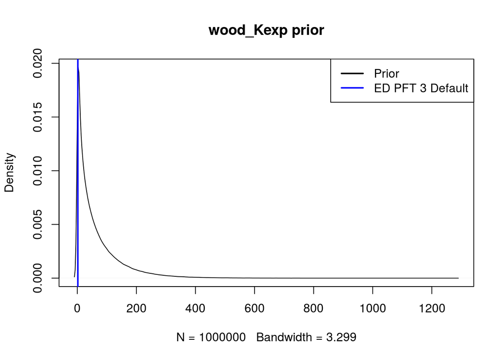

```r
wood_Kexp_fit <- tbl(bety, "priors") %>% filter(id == wood_Kexp_prior_id) %>% collect()
wood_Kexp_prior <- rdistn(wood_Kexp_fit)

# Calculating this by hand psi50 is calculated wrong in ED!
default_wood_Kexp <- 0.544 * 4. * (-default_wood_psi50 / MPa2m) ^ (-0.17)
wrong_default_wood_Kexp <- get_ED_default(PFT3_defaults_history, "wood_Kexp")


plot(density(wood_Kexp_prior), main = "wood_Kexp prior")
abline(v = default_wood_Kexp, col = "blue", lwd = 2)
abline(v = wrong_default_wood_Kexp, col = "blue", lwd = 1, lty = 2)
legend("topright",legend=c("Prior","ED PFT 3 Default"), col=c("black", "blue"), lwd=2)
```

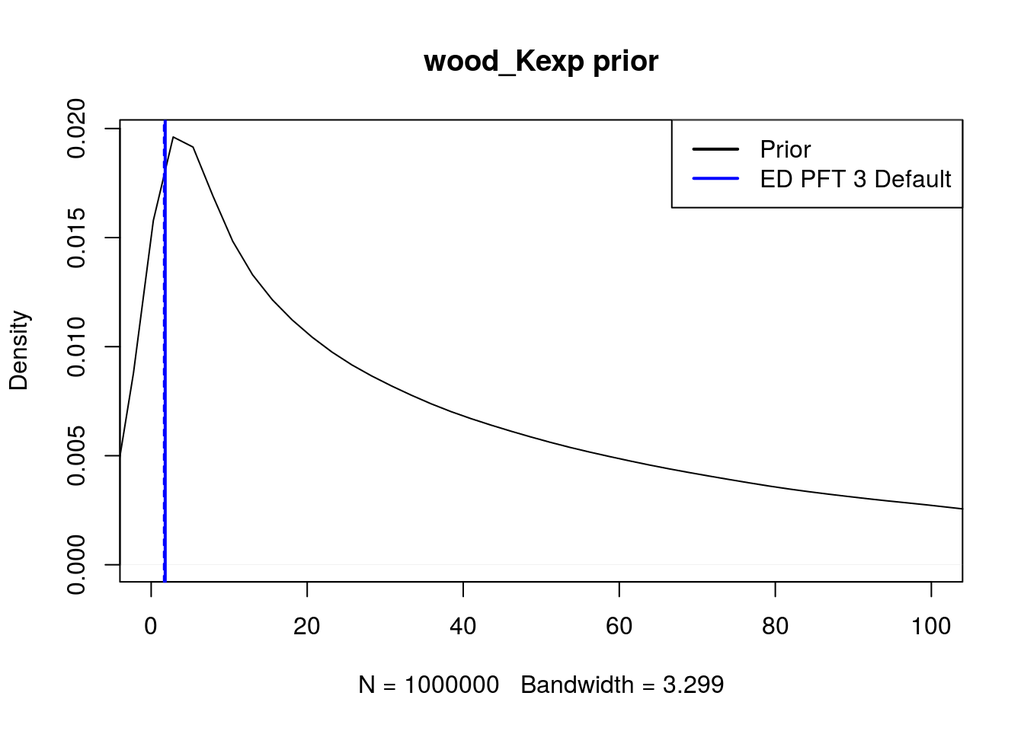

```r
plot(density(wood_Kexp_prior), main = "wood_Kexp prior", xlim = c(0, 100))
abline(v = default_wood_Kexp, col = "blue", lwd = 2)
abline(v = wrong_default_wood_Kexp, col = "blue", lwd = 1, lty = 2)
legend("topright",legend=c("Prior","ED PFT 3 Default"), col=c("black", "blue"), lwd=2)
```

## Wood psi min

- ED variable name : `wood_psi_min`

### Calculation

Should I put wood_rwc_min and rwc_tlp_wood in the database too

leaf_rwc_min_samp = 0.01 * leaf_elastic_mod_prior + 0.17 leaf_psi_min_samp = (leaf_rwc_min_samp - 1.) * leaf_water_sat_prior / leaf_water_cap_prior

```r
rwc_tlp_wood_samp <- 1. - (1. - 0.75 * wood_density_prior) / (2.74 + 2.01 * wood_density_prior)
wood_rwc_min_samp = wood_elastic_mod_prior * (1. - rwc_tlp_wood_samp) / (wood_psi_osmotic_prior / MPa2m) + 1.
wood_psi_min_samp = (wood_rwc_min_samp - 1.) * wood_water_sat_prior / wood_water_cap_prior

qs <- quantile(wood_psi_min_samp, c(.025,.25,.5,.75,.975))
myfit <- fitdist(vals = qs, probs =c(.025,.25,.5,.75,.975))

variable_id.in <- tbl(bety, "variables") %>% filter(name == "wood_psi_min") %>% pull(id)
phylogeny.in <- "plants"
distn.in <- myfit$ssq %>% dplyr::select(one_of("Normal", "Gamma", "Log normal", "Beta")) %>%
  which.min %>% names

wood_psi_min_prior_id <- input_prior(bety, myfit, variable_id.in, phylogeny.in, distn.in)
```

```
## [1] "Entry with id = 1000000399 already exists with different parameters. Old: norm(-1792.1241, 1320.0761) New: norm(-1798.2191, 1327.2773)"
```

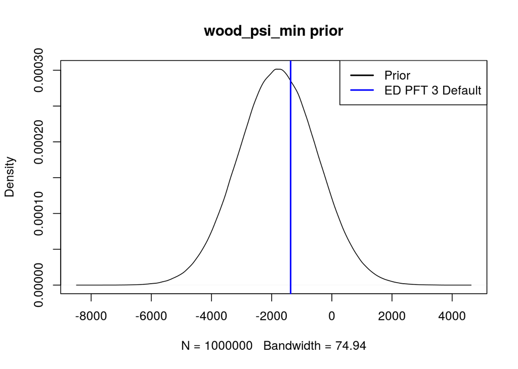

```r
wood_psi_min_fit <- tbl(bety, "priors") %>% filter(id == wood_psi_min_prior_id) %>% collect()
wood_psi_min_prior <- rdistn(wood_psi_min_fit)

plot(density(wood_psi_min_prior), main = "wood_psi_min prior")
abline(v = get_ED_default(PFT3_defaults_history, "wood_psi_min"), col = "blue", lwd = 2)
legend("topright",legend=c("Prior","ED PFT 3 Default"), col=c("black", "blue"), lwd=2)
```